# Local RNA-seq QC Report

# Local RNA-seq QC Report

Generated on: 2026-09-08 16:17:00.568572

This report summarizes the local RNA-seq/cfRNA QC outputs generated by the pipeline.

# 1. Run status

```
## All scheduled modules ran correctly.
```

**Show run-status table**

**Pipeline step status**

| step | script | status | start_time | end_time | error_message |
| --- | --- | --- | --- | --- | --- |
| 01_normalize_log | /Users/maherhabboub/Desktop/University/Thesis/cfRNA_QC_tool/Local_tool/scripts/01_normalize_log.R | PASS | 2026-09-08T16:16:39Z | 2026-09-08T16:16:46Z |  |
| 02_biotype_distribution | /Users/maherhabboub/Desktop/University/Thesis/cfRNA_QC_tool/Local_tool/scripts/02_biotype_distribution.R | PASS | 2026-09-08T16:16:46Z | 2026-09-08T16:16:48Z |  |
| 03_pca_top_variable_genes | /Users/maherhabboub/Desktop/University/Thesis/cfRNA_QC_tool/Local_tool/scripts/03_pca_top_variable_genes.R | PASS | 2026-09-08T16:16:48Z | 2026-09-08T16:16:50Z |  |
| 04_ssgsea_score | /Users/maherhabboub/Desktop/University/Thesis/cfRNA_QC_tool/Local_tool/scripts/04_ssgsea_score.R | PASS | 2026-09-08T16:16:50Z | 2026-09-08T16:16:58Z |  |
| 05_sex_inference_XIST_vs_Ypanel | /Users/maherhabboub/Desktop/University/Thesis/cfRNA_QC_tool/Local_tool/scripts/05_sex_inference_XIST_vs_Ypanel.R | PASS | 2026-09-08T16:16:58Z | 2026-09-08T16:16:59Z |  |
| 07_hpc_metric_pc_correlation | /Users/maherhabboub/Desktop/University/Thesis/cfRNA_QC_tool/Local_tool/scripts/07_hpc_metric_pc_correlation.R | SKIPPED | 2026-09-08T16:16:59Z | 2026-09-08T16:16:59Z | No HPC_SUMMARY path configured. |

# 2. Normalization and log-transformation QC

DESeq2 size-factor normalization adjusts counts for differences in sequencing depth and library composition, while log transformation stabilizes the mean-variance relationship. After normalization, sample density curves should generally become more comparable, reflecting reduced technical scale differences. Marked residual separation may still reflect genuine biological heterogeneity or remaining technical variation and should be interpreted with the study design in mind.

**Show additional normalization plots**

## Before/after histogram

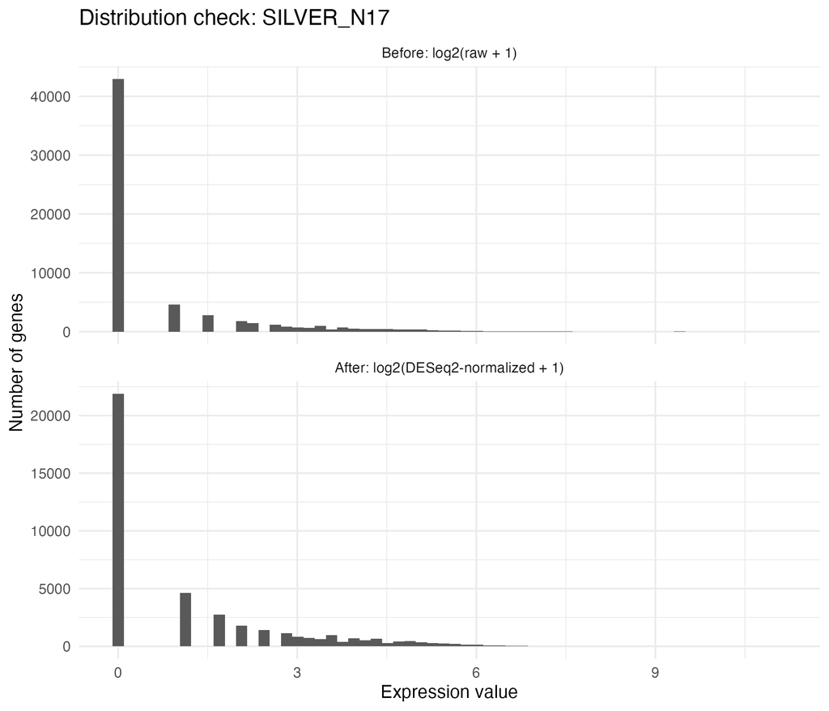

## Library size check

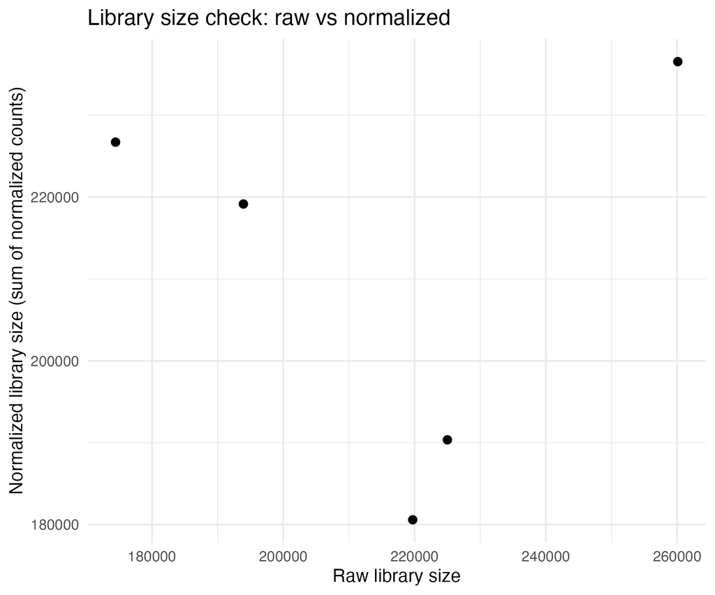

## Density curves before normalization

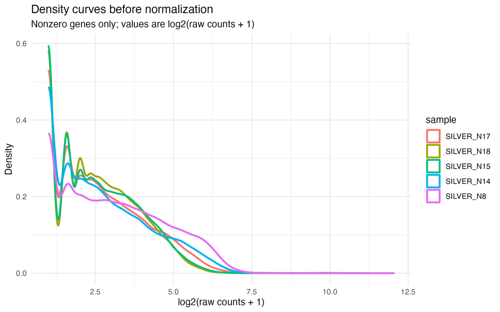

## Density curves after normalization

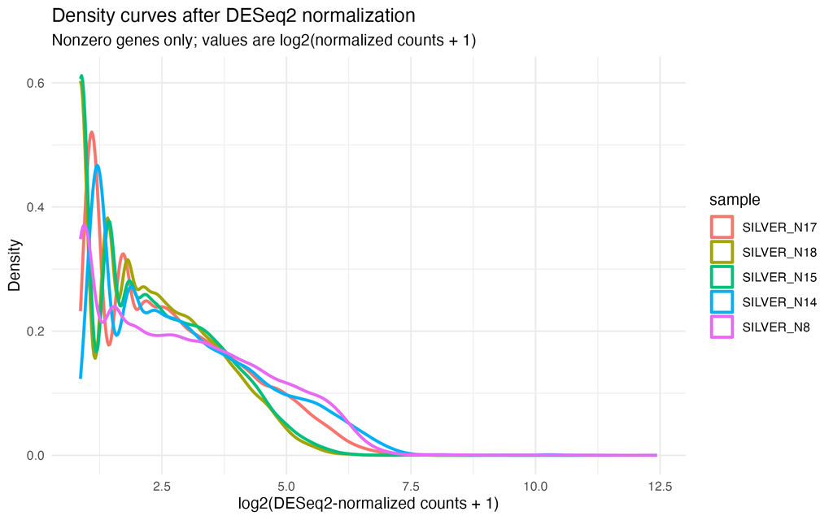

# 3. Biotype distribution QC

This count-level QC assesses whether reads are predominantly assigned to expected transcript classes, such as protein-coding genes and long non-coding RNAs (lncRNAs). A typical RNA-seq profile is expected to be enriched for these biologically plausible classes, whereas elevated fractions of unexpected classes should prompt review of library preparation, annotation compatibility, alignment, and count assignment.

## Biotype distribution plot

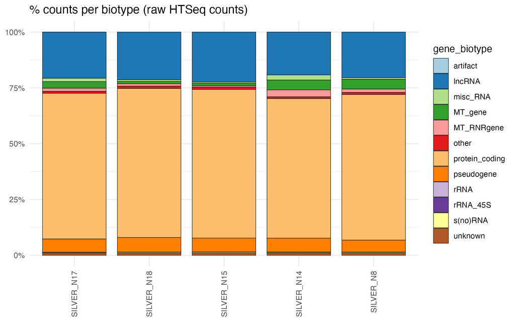

**Show biotype distribution table**

**Biotype distribution table**

| gene_biotype | sample_id | count | frac |
| --- | --- | --- | --- |
| MT_RNRgene | SILVER_N17 | 2736 | 0.0141085471187315 |
| MT_RNRgene | SILVER_N18 | 2386 | 0.0108594731380509 |
| MT_RNRgene | SILVER_N15 | 1455 | 0.00646669540753514 |
| MT_RNRgene | SILVER_N14 | 5438 | 0.0311724343504405 |
| MT_RNRgene | SILVER_N8 | 4030 | 0.0154940407535563 |
| MT_gene | SILVER_N17 | 5712 | 0.0294546860899832 |
| MT_gene | SILVER_N18 | 2264 | 0.0103042108904222 |
| MT_gene | SILVER_N15 | 2193 | 0.00974670998537771 |
| MT_gene | SILVER_N14 | 7689 | 0.0440759190365092 |
| MT_gene | SILVER_N8 | 11436 | 0.0439677047289504 |

[output cut: 50 more lines]

# 4. PCA on top variable genes

Principal component analysis (PCA) is a dimensionality-reduction method that summarizes the high-dimensional expression matrix into orthogonal principal components (PCs), ordered by the amount of variation they explain. Samples that lie close together in PCA space have more similar overall expression profiles.

The scree plot shows the proportion of variability captured by successive PCs. When metadata are supplied, the coloured PCA plots help assess whether sample separation is aligned with the experimental condition, as may be expected for a biological contrast, or with batch and other technical annotations, which can indicate unwanted variation.

## PCA scatter plot

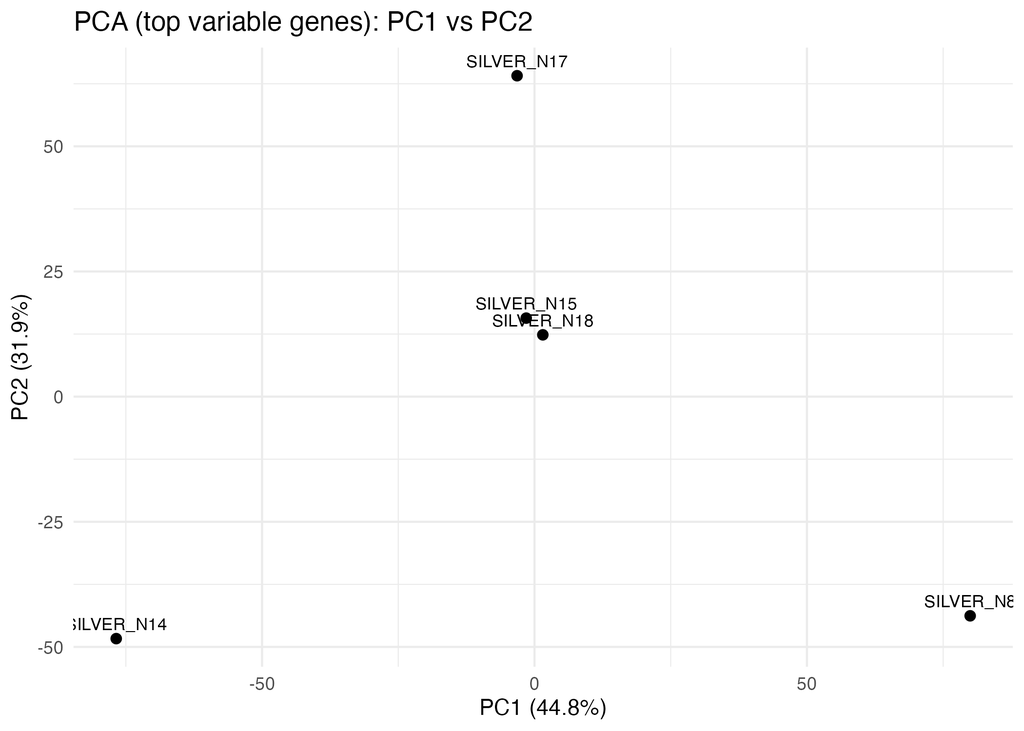

## Scree plot

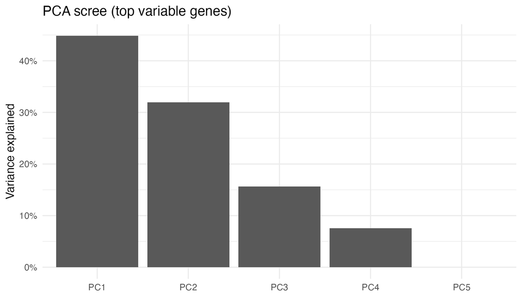

*No metadata-colored PCA plots were generated.*

**Show PCA variance-explained table**

**PCA variance explained**

| PC | variance_explained | cumulative |
| --- | --- | --- |
| PC1 | 0.448414925472026 | 0.448414925472026 |
| PC2 | 0.319368955694813 | 0.767783881166838 |
| PC3 | 0.156550702709123 | 0.924334583875961 |
| PC4 | 0.0756654161240388 | 1 |
| PC5 | 3.96148576131178e-31 | 1 |

# 5. Gene-set contamination scores

Single-sample gene-set enrichment analysis (ssGSEA) produces a per-sample enrichment score for each marker set. The platelet, erythroid/hemolysis, and endothelial sets are included because these signals can represent problematic contamination or compositional effects in cfRNA data. The heatmap tests whether these scores track the major expression PCs; the absence of strong or statistically supported score-PC correlations is generally reassuring, whereas a substantial significant association suggests that a leading PC may reflect one of these contamination-associated signals.

## ssGSEA score versus PC correlation heatmap

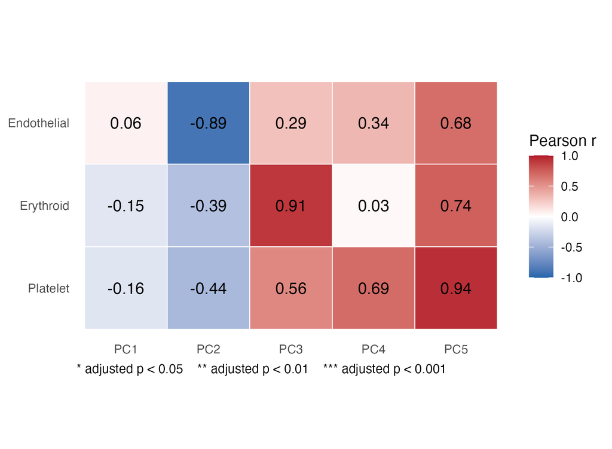

**Show individual gene-set plots and tables**

## Platelet score vs PC1

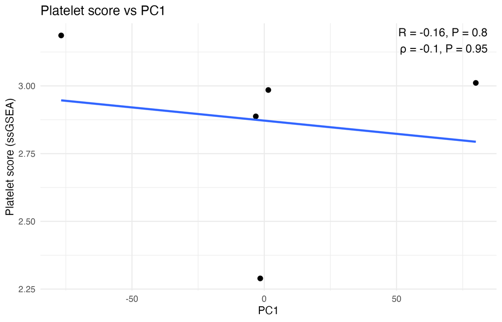

## Erythroid/hemolysis score vs PC1

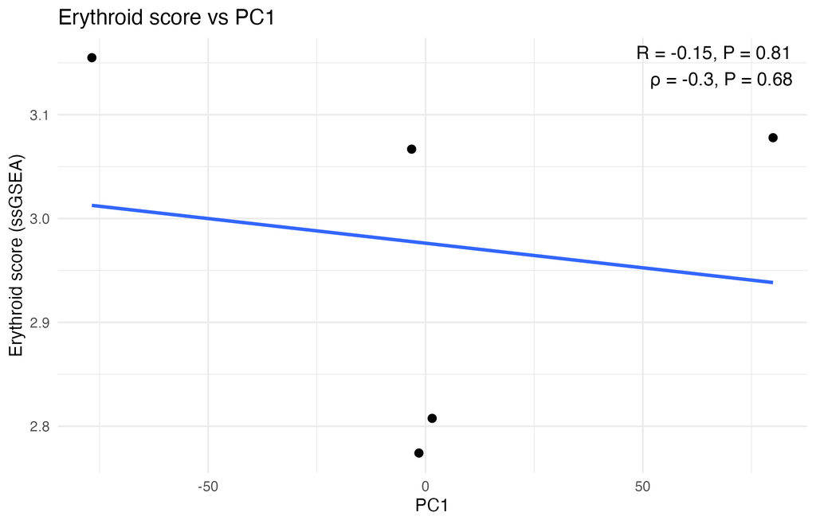

**Show ssGSEA scores table**

**ssGSEA scores**

| sample_id | platelet_score_ssgsea | erythroid_score_ssgsea | endothelial_score_ssgsea |
| --- | --- | --- | --- |
| SILVER_N17 | 2.88753333803887 | 3.06684732674525 | 2.2281902880291 |
| SILVER_N18 | 2.98487829584332 | 2.80760279179315 | 2.42865129951705 |
| SILVER_N15 | 2.28944526127667 | 2.77415177485332 | 2.18622353888322 |
| SILVER_N14 | 3.18622353888322 | 3.15494376125321 | 2.66284593658785 |
| SILVER_N8 | 3.01104013418033 | 3.07787450884332 | 2.67839586339698 |

**Show ssGSEA marker matching statistics**

**Marker matching statistics**

| set | panglao_pattern | markers_in_panglao | markers_mapped_to_ensg | markers_found_in_matrix |
| --- | --- | --- | --- | --- |
| Platelet | platelet | 131 | 148 | 124 |
| Erythroid | erythroid\|hemoglobin\|erythro | 102 | 92 | 88 |
| Endothelial | endothelial | 292 | 296 | 263 |

# 6. Sex chromosome QC

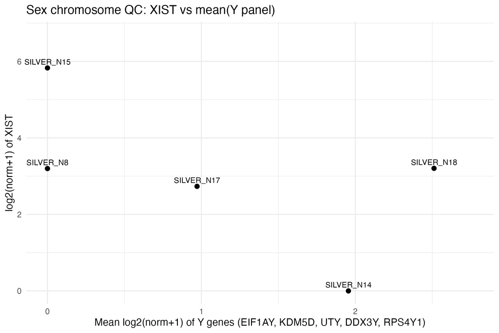

**Show sex chromosome QC scores table**

**Sex chromosome QC scores**

| sample_id | XIST_log2norm | Y_panel_mean_log2norm | Y_genes_used |
| --- | --- | --- | --- |
| SILVER_N17 | 2.73345608520674 | 0.971697226874243 | 4 |
| SILVER_N18 | 3.20457257580669 | 2.51121371611258 | 4 |
| SILVER_N15 | 5.8287208380246 | 0 | 4 |
| SILVER_N14 | 0 | 1.95507807070392 | 4 |
| SILVER_N8 | 3.19925521287366 | 0 | 4 |

**Show sex chromosome marker matching-statistics table**

**Sex chromosome marker matching statistics**

| marker_type | markers_expected | markers_resolved_to_ensg | markers_found_in_matrix | genes_found |
| --- | --- | --- | --- | --- |
| XIST | 1 | 1 | 1 | XIST |
| Y_panel | 5 | 5 | 4 | EIF1AY,KDM5D,UTY,DDX3Y |

# Notes

- Correlation heatmaps show **Pearson r** values.
- Significance stars, when present, use BH-adjusted p-values:
  - `*` adjusted p < 0.05
  - `**` adjusted p < 0.01
  - `***` adjusted p < 0.001
- Missing optional plots/tables usually mean that the corresponding optional input was not provided, or that the module was skipped.